# Finding Trump Storytelling Document

Antonio Skilton

## Introduction

The 2016 Presidential Election laid bare the extent to which I was uninformed about the makeup of the American electorate. As the results poured in over the course of the evening of November 8th, the surprises kept piling up. First came Florida, where exit polls had showed a surge of Latinos who were predicted to decisively tilt the state to Clinton, ensuring a quick victory. Next was Virginia, which showed an unexpectedly tight race (though Hillary Clinton still won that state in the end). These early surprises highlighted the remaining political power of White voters, who despite making up a record low percentage of the vote (70%) broke for the GOP in record numbers. The trend continued in all swing states except Nevada, clinching the electoral votes required for the nomination.

Hillary Clinton was widely seen as the inevitable successor to President Barack Obama. Given the election outcome and the staggering amount of data we collect about ourselves, it is odd that we were so wrong. We have extensive data regarding race, income, age, health status, sex, and more. Pollsters constantly surveyed voters and had seasoned models for predicting voter turnout. Before Trump’s election, some poll aggregators had cautioned pundits who underestimated the uncertainty of predictions of a Clinton win by citing the fact that polling errors regularly match the margin with which Clinton was thought to be leading Trump.

However, even the obsessive consumer of American politics (such as myself) was left with the impression that there was no plausible argument to be made that a Trump victory was possible. Although part of that mistaken assessment of mine is attributable to political bias, it could not explain all. The reality is that despite my undergraduate degrees in both sociology and economics, I felt demographically illiterate. I was aware that there were stark differences between people in urban and rural areas, but had previously attributed the major demographic divide in America to race. Although race clearly played a role in this election, it was clear that something else was at play as well. The research question behind this project, in sum, is as follows: What demographic realities in the United States exist that should have a Trump victory appear possible? To be clear, I am not attempting to explain how Donald Trump won the election, as I have no intention of delving into Electoral College math or voter propensity models.

## The Research

To answer my research question I had to pick a unit of analysis. I settled on counties for two reasons:

1. Counties are a small enough unit of analysis that basic demographic statistics are likely to be accurate across most residents. This is not true of states or larger geographic bodies.
2. There are extensive statistics describing counties. This is not true of towns or cities, whose boundaries are more likely to change, and for which statistics are not publicly available to the same extent.

#### Race

As stated above and shown in the chart below, the vast majority of counties in the United States are majority white. While it may be self evident that the United States is majority White, county level analysis truly demonstrates the extent to which this is true.

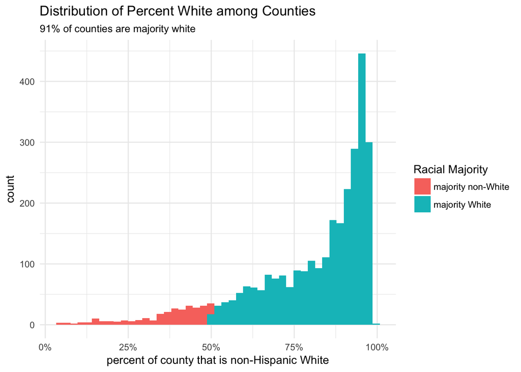

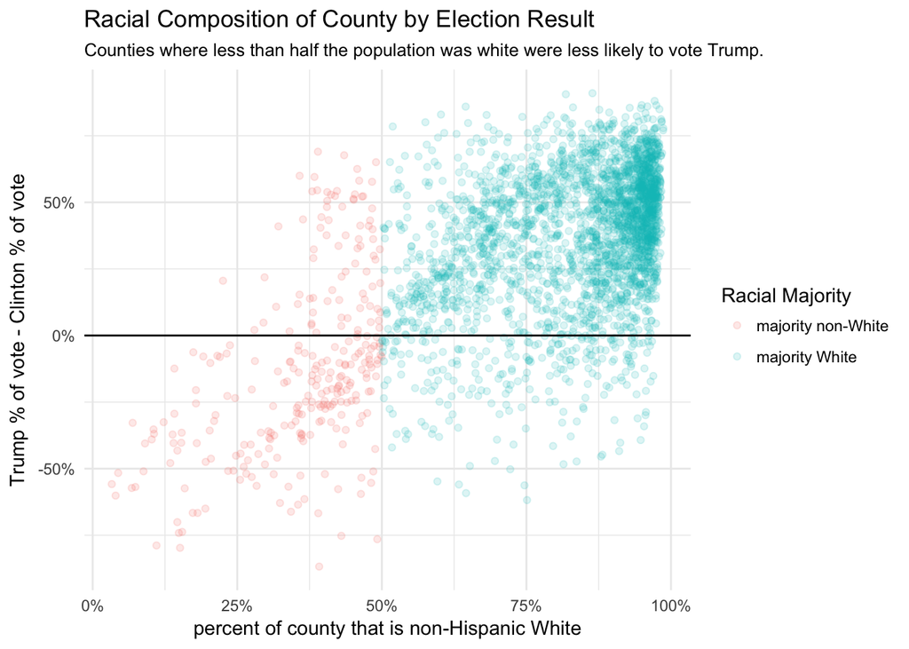

#### Education

While the division between education levels might not seem as stark as those defined by race, they nevertheless have a significant relationship with election results.

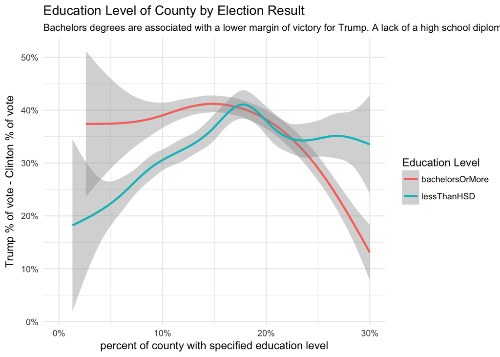

#### Income

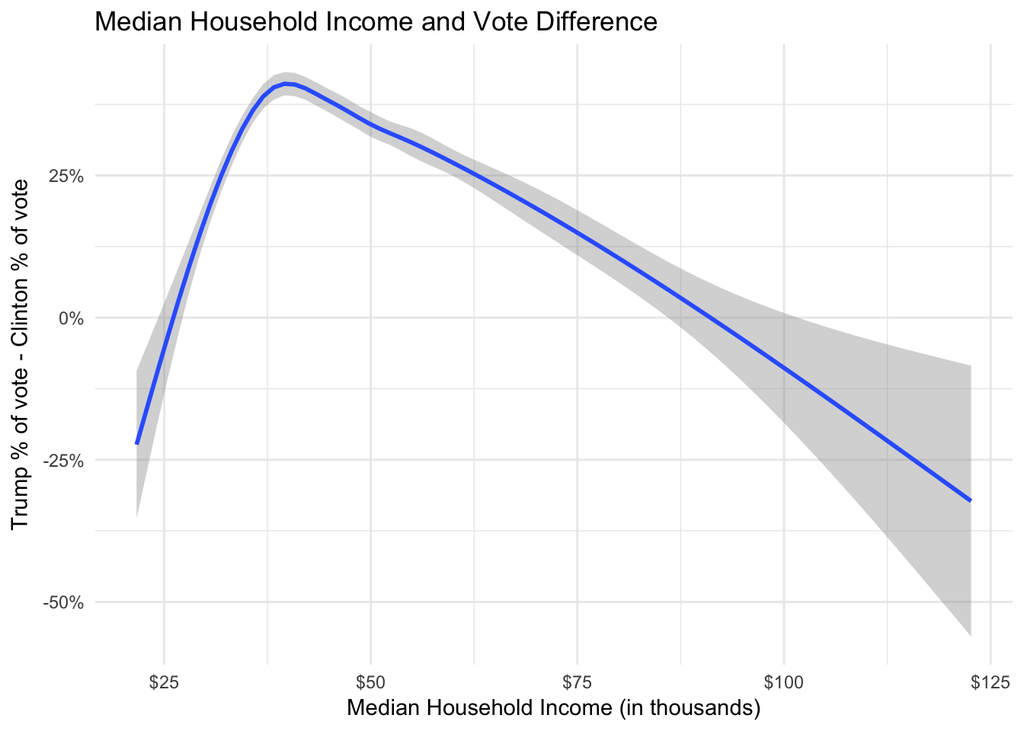

#### Income and Race

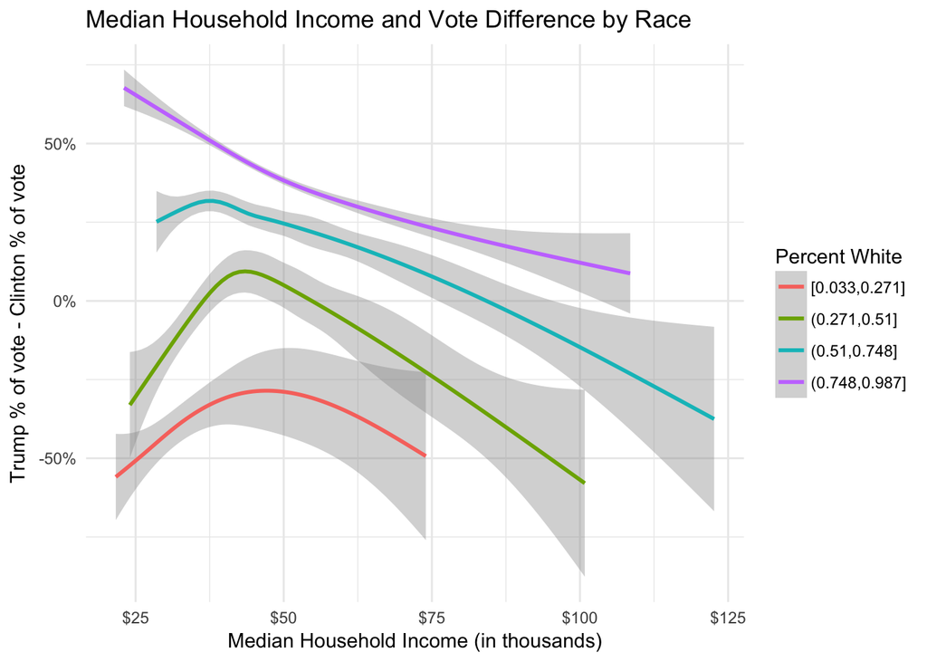